# Defensive positioning — visual EDA

**Mission:** Football defensive positioning. How can tracking and contextual data help us better understand the way players and teams defend?

Dataset: **20** A-League 2024/25 matches (SkillCorner Open Data) — phases of play + dynamic events (pressure, engagements, structure labels). Tracking JSONL stubs are not used here; contextual fields already encode shape, pressure, and marking.

Counts: 8,834 phases · 18,710 possessions · 17,445 on-ball engagements.

```python
from pathlib import Path
from IPython.display import Image, display, Markdown
FIG = Path('output/figures')
print('Figures:', sorted(p.name for p in FIG.glob('*.png')))
```

```
Figures: ['01_phase_mix.png', '02_shape_scatter.png', '03_compactness_violin.png', '04_pressure_ladder.png', '05_pressure_x_block_heatmap.png', '06_engagement_outcomes.png', '07_engagement_heatmaps.png', '08_structure_labels.png', '09_line_height_by_block.png', '10_decision_flags.png', '11_pressing_…
```

## 1. Team defensive context (phase mix)

Organized blocks dominate minutes; shot rate climbs as the block drops.

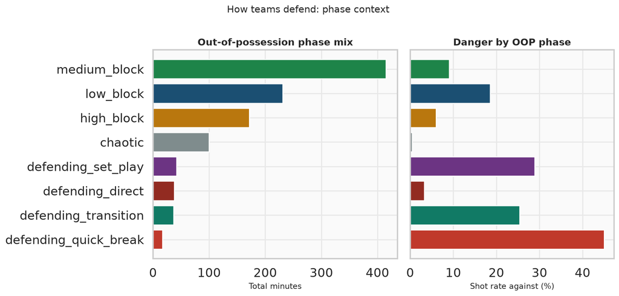

```python
display(Image(filename=str(FIG / '01_phase_mix.png')))
```

## 2. Team shape

OOP width × length. Shot phases (red) sit toward the compact side of the cloud.

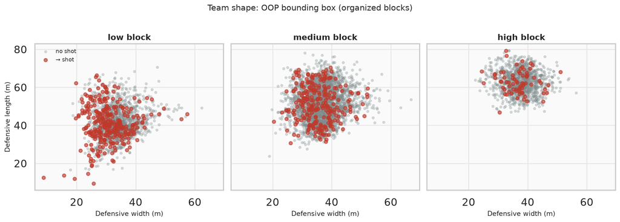

```python
display(Image(filename=str(FIG / '02_shape_scatter.png')))
```

## 3. Compactness

Box area / width / length split by shot vs no-shot inside each organized block.

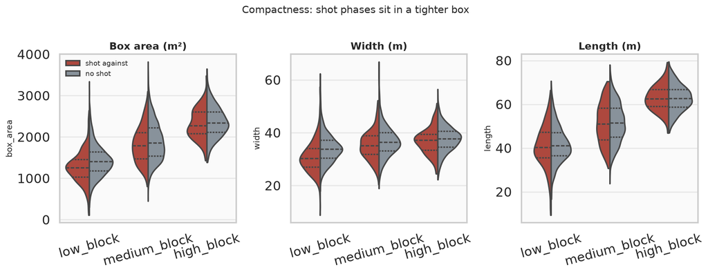

```python
display(Image(filename=str(FIG / '03_compactness_violin.png')))
```

## 4. Pressure

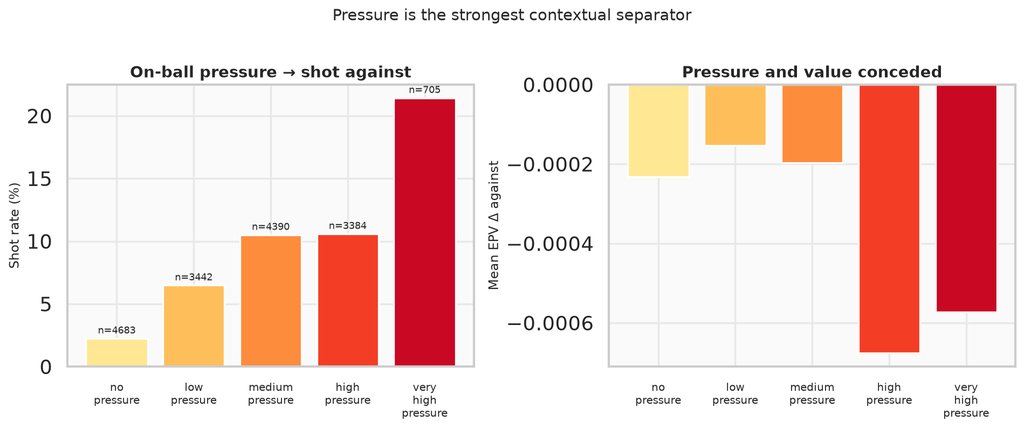

```python
display(Image(filename=str(FIG / '04_pressure_ladder.png')))
```

## 5. Pressure × block

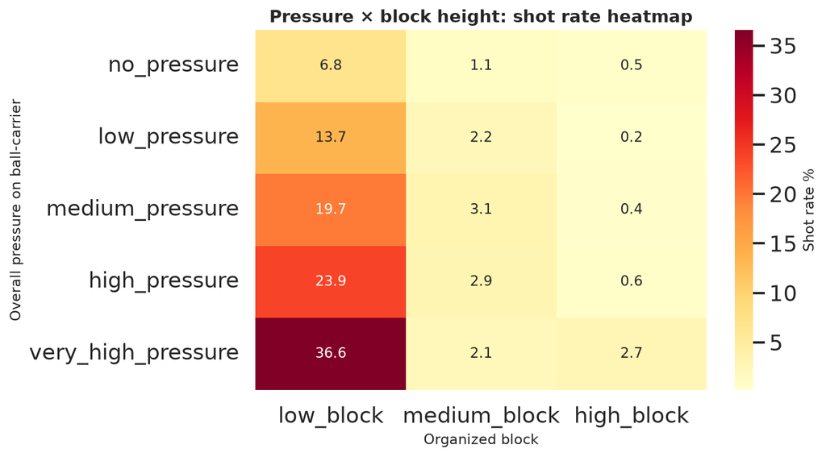

```python
display(Image(filename=str(FIG / '05_pressure_x_block_heatmap.png')))
```

## 6. Marking / pressing actions

Engagement subtypes: volume, regain rate, lead-to-shot.

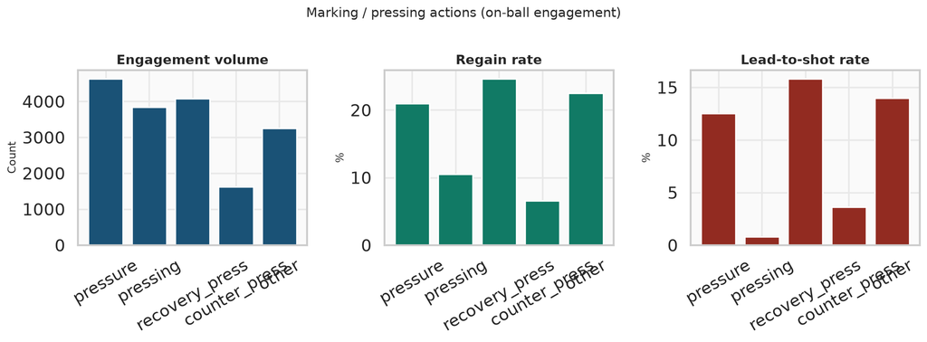

```python
display(Image(filename=str(FIG / '06_engagement_outcomes.png')))
```

## 7. Where defenders engage

Pitch heatmaps by engagement subtype.

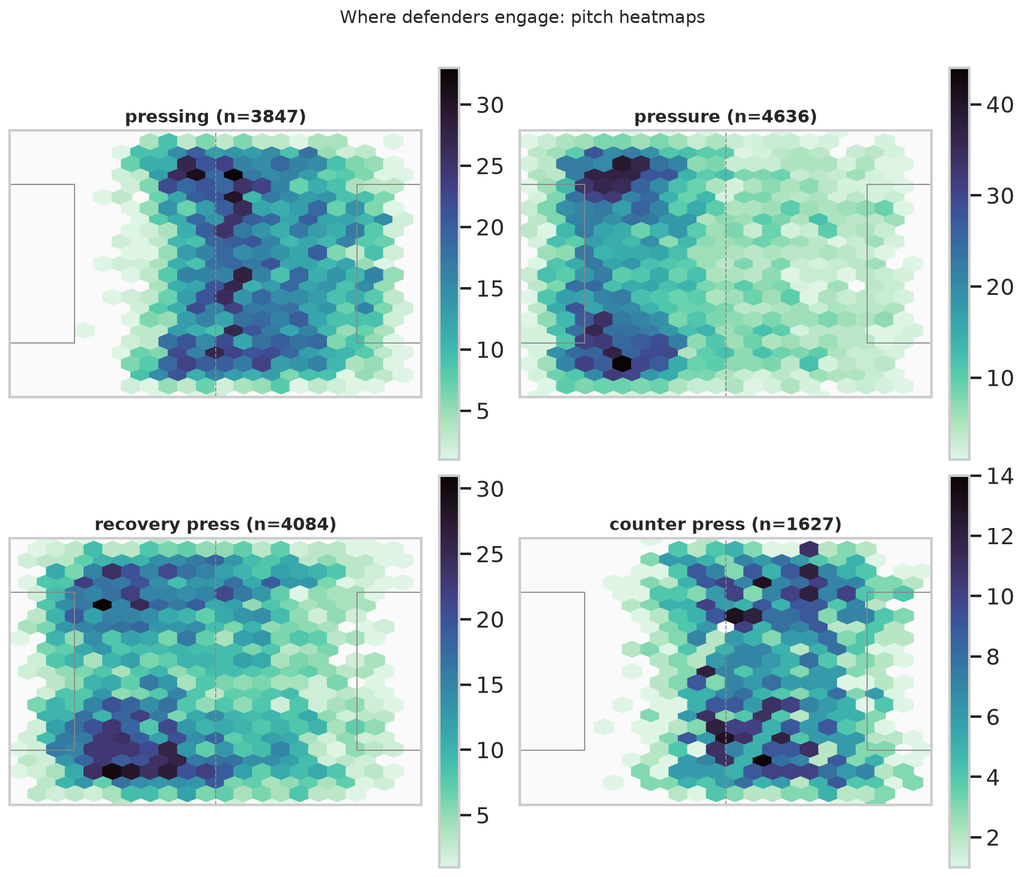

```python
display(Image(filename=str(FIG / '07_engagement_heatmaps.png')))
```

## 8. Defensive structure labels

Organised defense, number of lines, ball inside shape.

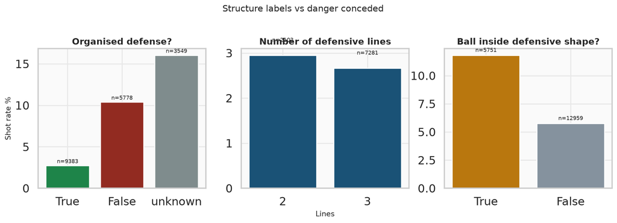

```python
display(Image(filename=str(FIG / '08_structure_labels.png')))
```

## 9. Line height

Last defensive line height distributions validate block labels.

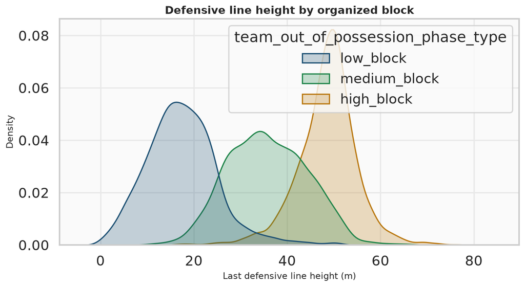

```python
display(Image(filename=str(FIG / '09_line_height_by_block.png')))
```

## 10. Defensive decisions

Force backward / stop danger / beaten flags vs subsequent shot rate.

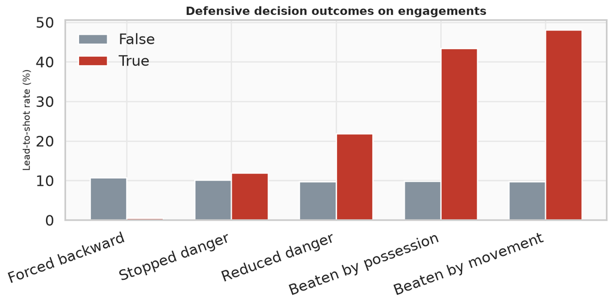

```python
display(Image(filename=str(FIG / '10_decision_flags.png')))
```

## 11. Pressing chains

Coordinated pressure sequences.

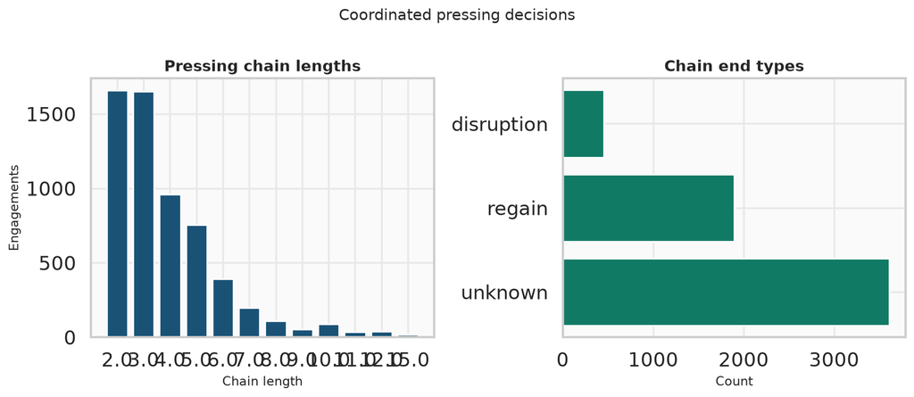

```python
display(Image(filename=str(FIG / '11_pressing_chains.png')))
```

## 12. Team board

Which sides defend in a bigger box — and how that relates to shots against.

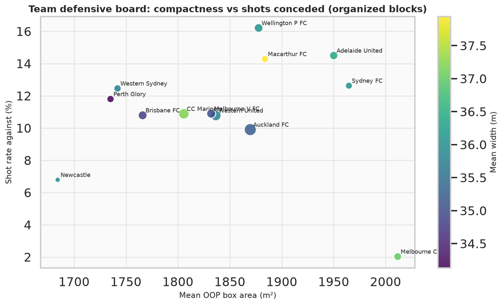

```python
display(Image(filename=str(FIG / '12_team_defense_board.png')))
```

## 13. Spacing at engagement

Distance to ball-carrier by subtype and shot rate by distance bin.

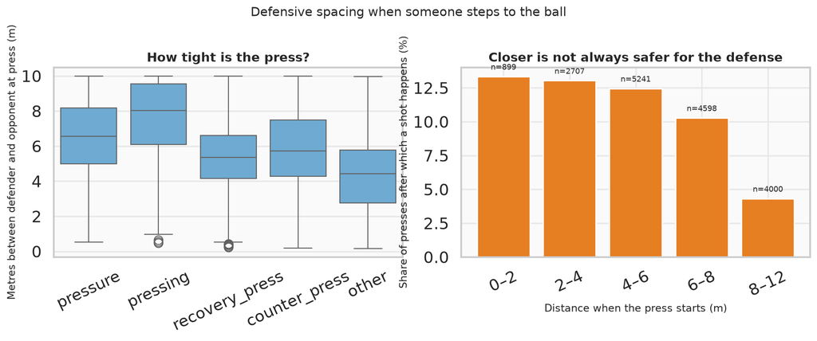

```python
display(Image(filename=str(FIG / '13_engagement_spacing.png')))
```

## 14. Two axes of defense

Within-block compactness tertiles vs pressure gradients.

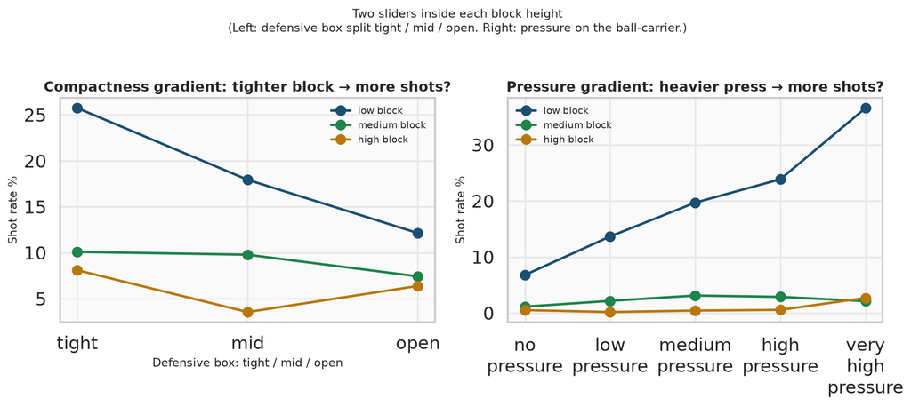

```python
display(Image(filename=str(FIG / '14_compactness_vs_pressure_gradients.png')))
```

## 15. Spatial danger map

Possessions that become shots by pitch third × channel.

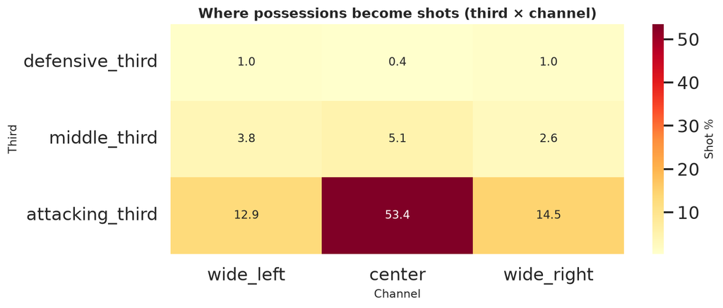

```python
display(Image(filename=str(FIG / '15_third_channel_heatmap.png')))
```

## Takeaways for coaches / analysts

**Next film questions:** (1) moments where the box looks compact but pressure is low; (2) engagements where the defender is beaten by movement; (3) team outliers on the compactness–shot board.